# Notebook

### NOTICE:

1. Mechanical correctness of your python codes: your codes must be accurate
2. Clarity of jupyter notebook and organization of outputs:
- The python codes you write must be accompanied with "comments" using # or markdown
- All outputs must be visible in your jupyter notebook. If necessary, explain the outputs using markdown.
- **Do not print out an entire output. Print the first five rows**
3. Formatting: **"This exam must contain K-State Honor Code "On my honor, as a student, I have neither given nor received unauthorized aid on this academic work."**
- A **grade of XF** can result from a breach of academic honesty. The F indicates failure in the course; the X indicates the reason is an Honor Pledge violation.” (http://www.k-state.edu/provost/resources/teaching/course.htm (Links to an external site.)) (See Academic Dishonesty below).
- **Unauthorized collaboration** (including but not limited to collaborating with other students on the midterm exam is forbidden)
- **Unauthorized aid** (including but not limited to sharing your codes with other students, receiving codes from another)
- **Plagiarism** (including but not limited to copying words of another (on the Internet or articles) as your own)(please credit the references/sources)

```python
# run the following syntax and sign with your full name
input("Please sign the E-Signature (full name):")
```

```
'Saloni Prakash'
```

# Final Project Part III

## Data Preparation

```python
from google.colab import files
import pandas as pd

# Upload CSV file
uploaded = files.upload()

# Read CSV into DataFrame
df = pd.read_csv(list(uploaded.keys())[0])
df.head()
```

Upload widget is only available when the cell has been executed in the current browser session. Please rerun this cell to enable.

```
Saving maib_reports_summary.csv to maib_reports_summary.csv
```

|  | Title | Publication Date | Vessel Type | Report Type | Incident URL | Location | Summary | Safety Issue | Recommendations |
| --- | --- | --- | --- | --- | --- | --- | --- | --- | --- |
| 0 | Fatal accident on board the recreational saili... | 5 August 2025 | Vessel type: Recreational craft - sail | Completed preliminary assessment | https://www.gov.uk/maib-reports/fatal-accident... | The Solent, England. | Shortly before 1218[footnote 1] on 5 August 20... | The skipper died after being pulled into the r... | Earlier in the day, Mollie had departed from W... |
| 1 | Two persons overboard from the standby safety ... | 25 August 2025 | Vessel type: Merchant vessel 100 gross tons or... | Completed preliminary assessment | https://www.gov.uk/maib-reports/two-persons-ov... | North Sea. | At 0800 on 25 August 2025, the deck crew of th... | The FRC cradle had a narrow outboard arm (Figu... | Although the planned work was initially schedu... |
| 2 | Cargo hold fire on the bulk carrier Altay whil... | 27 June 2025 | Vessel type: Merchant vessel 100 gross tons or... | Completed preliminary assessment | https://www.gov.uk/maib-reports/cargo-hold-fir... | Hull, England. | On the morning of 27 June 2025, the Marshall I... | The fire was likely caused by an undischarged ... | At 0948, the master observed smoke rising from... |
| 3 | Uncontrolled launching of fast rescue craft fr... | 23 August 2025 | Vessel type: Merchant vessel 100 gross tons or... | Completed preliminary assessment | https://www.gov.uk/maib-reports/uncontrolled-l... | Lochboisdale, Scotland. | At 1645 on 23 August 2025, the crew of the pas... | updated the stored power launching procedure a... | At 1558, Lord of the Isles departed Lochboisda... |
| 4 | Fatal injury to a recreational diver following... | 28 September 2023 | Vessel type: Merchant vessel under 100 gross tons | Investigation report | https://www.gov.uk/maib-reports/fatal-injury-t... | Scapa Flow, Orkney Islands, Scotland. | On the morning of 28 September 2023, a recreat... | it is the responsibility of skippers to mainta... | Statement from the Chief Inspector of Marine A... |

# Preparing data for analysis with clean pipeline

```python
import re
from nltk.tokenize import word_tokenize
from nltk.corpus import stopwords
from nltk.stem import WordNetLemmatizer
from nltk.tag import pos_tag
import nltk
nltk.download('punkt_tab')
nltk.download('stopwords')
nltk.download('wordnet')
nltk.download('averaged_perceptron_tagger_eng')


# Initialize lemmatizer
lemmatizer = WordNetLemmatizer()

def clean_text_pipeline(text):
    """
    Clean text for NLP:
    - lowercase
    - tokenize
    - remove stopwords
    - lemmatize
    - keep nouns, adjectives, adverbs
    - remove special characters (keep letters & numbers)
    """

    # Lowercase
    text = text.lower()

    # Remove special characters except spaces
    text = re.sub(r"[^a-zA-Z0-9\s]", " ", text)

    # Tokenize
    tokens = word_tokenize(text)

    # Remove stopwords
    stop_words = set(stopwords.words("english"))
    tokens = [w for w in tokens if w not in stop_words]

    # Lemmatize
    lemma_tokens = [lemmatizer.lemmatize(w) for w in tokens]

    # POS tagging
    tagged_tokens = pos_tag(lemma_tokens)

    # Keep nouns, adjectives, adverbs
    filtered_tokens = [
        w for w, t in tagged_tokens if t.startswith("NN") or t.startswith("JJ") or t.startswith("RB")
    ]

    # Join back into string
    clean_text = " ".join(filtered_tokens)

    return clean_text
```

### Taking safety issue column for analysis

```python
# Apply clean_pipeline
df['clean_safety'] = df['Safety Issue'].astype(str).apply(clean_text_pipeline)

df.head()
```

|  | Title | Publication Date | Vessel Type | Report Type | Incident URL | Location | Summary | Safety Issue | Recommendations | clean_safety |
| --- | --- | --- | --- | --- | --- | --- | --- | --- | --- | --- |
| 0 | Fatal accident on board the recreational saili... | 5 August 2025 | Vessel type: Recreational craft - sail | Completed preliminary assessment | https://www.gov.uk/maib-reports/fatal-accident... | The Solent, England. | Shortly before 1218[footnote 1] on 5 August 20... | The skipper died after being pulled into the r... | Earlier in the day, Mollie had departed from W... | skipper rope inboard aft winch probably right ... |
| 1 | Two persons overboard from the standby safety ... | 25 August 2025 | Vessel type: Merchant vessel 100 gross tons or... | Completed preliminary assessment | https://www.gov.uk/maib-reports/two-persons-ov... | North Sea. | At 0800 on 25 August 2025, the deck crew of th... | The FRC cradle had a narrow outboard arm (Figu... | Although the planned work was initially schedu... | frc cradle narrow outboard arm figure adequate... |
| 2 | Cargo hold fire on the bulk carrier Altay whil... | 27 June 2025 | Vessel type: Merchant vessel 100 gross tons or... | Completed preliminary assessment | https://www.gov.uk/maib-reports/cargo-hold-fir... | Hull, England. | On the morning of 27 June 2025, the Marshall I... | The fire was likely caused by an undischarged ... | At 0948, the master observed smoke rising from... | fire likely undischarged battery ignition sour... |
| 3 | Uncontrolled launching of fast rescue craft fr... | 23 August 2025 | Vessel type: Merchant vessel 100 gross tons or... | Completed preliminary assessment | https://www.gov.uk/maib-reports/uncontrolled-l... | Lochboisdale, Scotland. | At 1645 on 23 August 2025, the crew of the pas... | updated the stored power launching procedure a... | At 1558, Lord of the Isles departed Lochboisda... | stored power procedure vessel specific risk as... |
| 4 | Fatal injury to a recreational diver following... | 28 September 2023 | Vessel type: Merchant vessel under 100 gross tons | Investigation report | https://www.gov.uk/maib-reports/fatal-injury-t... | Scapa Flow, Orkney Islands, Scotland. | On the morning of 28 September 2023, a recreat... | it is the responsibility of skippers to mainta... | Statement from the Chief Inspector of Marine A... | responsibility skipper effective mean time vit... |

```python
import pandas as pd

# Replace NaNs in text columns with empty strings
for col in df.columns:
    if df[col].dtype == 'object':  # text columns
        df[col] = df[col].fillna('')
```

```python
for col in df.columns:
    if df[col].dtype != 'object':  # numeric or datetime columns
        df[col] = df[col].fillna(0)  # or another appropriate value
```

```python
# This will show number of missing values per column
print(df.isna().sum())
```

[output not shown]

### NMF

```python
from sklearn.decomposition import NMF
from sklearn.feature_extraction.text import TfidfVectorizer
from sklearn.pipeline import make_pipeline

# Use the cleaned Safety Issue column
docs = df['clean_safety'].tolist()  # Safety Issue text

# Set up NMF with TF-IDF
nmf_model = make_pipeline(
    TfidfVectorizer(stop_words='english'),
    NMF(n_components=10, random_state=0)  # adjust n_components as needed
)

# Train the model
NMF_result = nmf_model.fit_transform(docs)

# Extract components and feature names
nmf = nmf_model.named_steps['nmf']
tfidf = nmf_model.named_steps['tfidfvectorizer']
feature_names = tfidf.get_feature_names_out()

n_top_words = 10
topic_keywords = {}

# Grab the top n_top_words from each topic
for topic_idx, topic in enumerate(nmf.components_):
    top_features_idx = topic.argsort()[-n_top_words:][::-1]
    top_features = [feature_names[i] for i in top_features_idx]
    topic_keywords[f"Topic {topic_idx}"] = top_features

# Display the top words for each topic
print("Top topics for Safety Issues: \n")
for topic, keywords in topic_keywords.items():
    print(f"{topic}: {', '.join(keywords)}")
```

```
Top topics for Safety Issues:

Topic 0: nan, owner, buoy, daughter, norma, cabin, crane, grid, door, manufacturer
Topic 1: vessel, plan, collision, scot, pilot, voyage, bridge, tug, use, ecdis
Topic 2: loop, toggle, pfd, safety, eye, leg, unsuitability, creel, inadvertently, onboard
Topic 3: skipper, chance, personal, single, fishing, device, stability, vessel, risk, overboard
Topic 4: diver, dsmb, essential, surface, practice, need, effective, person, line, buoy
Topic 5: engine, control, fuel, hose, pipe, maintenance, flexible, auxiliary, hot, equipment
Topic 6: cargo, space, stevedore, access, hatch, safe, atmosphere, scrap, equipment, danger
Topic 7: boat, method, dover, rib, unsuitable, inflatable, ill, occupant, mobile, strait
Topic 8: chain, recovery, overboard, crew, risk, activity, member, net, water, immersion
Topic 9: trailer, semi, position, tractor, unit, door, deck, close, vehicle, banksman
```

Here the analysis shows that topic 8, covering man-overboard incidents and recovery, is highly important due to its direct impact on crew safety. Topic 5, related to engine and mechanical failures, also seems to be critical as it affects vessel operability and accident prevention. Navigation and collision risks, personal protective equipment issues, and cargo handling hazards are also key areas for intervention. Administrative and equipment-related issues, small boat operations, diving safety, and vehicle handling on deck highlight additional recurring risks. Overall, these findings provide actionable insights for maritime authorities and operators to prioritize safety measures, reduce accidents, and improve operational protocols.

## Gensim NMF model

```python
# Imports
import pandas as pd
from nltk.tokenize import word_tokenize
from nltk.corpus import stopwords
from nltk.stem import WordNetLemmatizer
import re
from gensim.corpora import Dictionary
from gensim.models import Nmf

# Preprocessing Function
lemmatizer = WordNetLemmatizer()
stop_words = set(stopwords.words("english"))

def clean_text_pipeline(text):
    """
    Clean text and return a list of lemmatized tokens (nouns, verbs, adjectives)
    """
    text = str(text).lower()
    text = re.sub(r"[^a-zA-Z\s]", " ", text)  # keep letters only
    tokens = word_tokenize(text)
    tokens = [lemmatizer.lemmatize(t) for t in tokens if t not in stop_words and len(t) > 2]
    return tokens

# Ensure Safety Issue column is string
df['Safety Issue'] = df['Safety Issue'].astype(str)

# Tokenize Safety Issue column
token_list = df['Safety Issue'].apply(clean_text_pipeline).tolist()

# Create Gensim dictionary and corpus
dictionary = Dictionary(token_list)
corpus = [dictionary.doc2bow(text) for text in token_list]

# Fit Gensim NMF Model
num_topics = 10
nmf_gensim = Nmf(
    corpus=corpus,
    num_topics=num_topics,
    id2word=dictionary,
    random_state=0
)

# --- Display Top Words per Topic ---
n_top_words = 10
topics = nmf_gensim.print_topics(num_words=n_top_words)

print(f"Top {num_topics} topics for Safety Issues using Gensim NMF:\n")
for idx, topic in enumerate(topics):
    print(f"Topic {idx + 1}: {topic}")
```

```
Top 10 topics for Safety Issues using Gensim NMF:

Topic 1: (0, '0.017*"fumigant" + 0.014*"thorco" + 0.014*"angela" + 0.013*"control" + 0.013*"emergency" + 0.012*"port" + 0.011*"vessel" + 0.011*"neither" + 0.010*"guidance" + 0.009*"use"')
Topic 2: (1, '0.027*"fumigant" + 0.022*"angela" + 0.022*"thorco" + 0.019*"cargo" + 0.013*"voyage" + 0.013*"diver" + 0.012*"board" + 0.012*"helm" + 0.009*"control" + 0.009*"provided"')
Topic 3: (2, '0.028*"crew" + 0.017*"vessel" + 0.017*"pilot" + 0.013*"bridge" + 0.012*"tug" + 0.012*"scot" + 0.011*"time" + 0.011*"master" + 0.010*"unable" + 0.010*"engine"')
Topic 4: (3, '0.035*"vessel" + 0.024*"crew" + 0.021*"fishing" + 0.015*"space" + 0.012*"safety" + 0.012*"operation" + 0.011*"stability" + 0.010*"working" + 0.010*"skipper" + 0.008*"winch"')
Topic 5: (4, '0.025*"risk" + 0.016*"buoy" + 0.013*"high" + 0.012*"assessment" + 0.011*"speed" + 0.008*"chain" + 0.008*"suspended" + 0.008*"vessel" + 0.007*"grid" + 0.007*"accident"')
Topic 6: (5, '0.011*"scot" + 0.011*"explorer" + 0.010*"vessel" + 0.009*"emergency" + 0.008*"navigational" + 0.008*"unit" + 0.008*"personal" + 0.008*"standard" + 0.008*"safe" + 0.008*"watch"')
Topic 7: (6, '0.027*"skipper" + 0.018*"safety" + 0.017*"working" + 0.014*"risk" + 0.014*"position" + 0.013*"shipyard" + 0.012*"fuel" + 0.011*"safe" + 0.011*"engine" + 0.009*"deck"')
Topic 8: (7, '0.024*"voyage" + 0.016*"frc" + 0.013*"strop" + 0.011*"change" + 0.011*"enc" + 0.011*"scale" + 0.010*"route" + 0.010*"electronic" + 0.010*"vessel" + 0.009*"information"')
Topic 9: (8, '0.017*"skipper" + 0.017*"winch" + 0.016*"hose" + 0.016*"chain" + 0.015*"system" + 0.014*"risk" + 0.011*"owner" + 0.010*"steering" + 0.010*"cargo" + 0.009*"link"')
Topic 10: (9, '0.030*"system" + 0.025*"safety" + 0.023*"boat" + 0.015*"due" + 0.015*"management" + 0.015*"vessel" + 0.011*"sea" + 0.010*"emergency" + 0.010*"response" + 0.010*"equipment"')
```

The results highlight frequent issues related to vessel operations, navigation planning, and emergency management. Mechanical and equipment-related risks such as engine, fuel, winch, and system failures appear across multiple topics, indicating maintenance as a critical safety concern. Several topics emphasize human factors, including skipper decision-making, crew safety practices, and vessel stability. Cargo handling and hazardous conditions also emerge, pointing to risks during loading and transport operations. Overall, this analysis confirms that marine accidents are driven by a combination of operational, mechanical, and organizational failures.

## Optimum topics

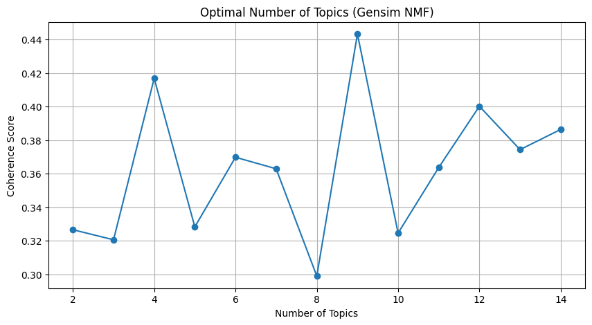

```python
from gensim.models.coherencemodel import CoherenceModel
import matplotlib.pyplot as plt

coherence_scores = []

for num in range(2, 15):
    # build NMF model for different numbers of topics
    nmf_model = Nmf(
        corpus=corpus,
        num_topics=num,
        id2word=dictionary,
        random_state=0
    )

    # compute coherence
    coherence_model = CoherenceModel(
        model=nmf_model,
        texts=token_list,
        dictionary=dictionary,
        coherence='c_v'
    )

    coherence_scores.append(coherence_model.get_coherence())

# plot coherence scores
plt.figure(figsize=(10, 5))
plt.plot(range(2, 15), coherence_scores, marker='o')
plt.title("Optimal Number of Topics (Gensim NMF)")
plt.xlabel("Number of Topics")
plt.ylabel("Coherence Score")
plt.grid(True)
plt.show()
```

```python
# Build the best NMF model using the optimum number of topics (9 from coherence)
nmf_gensim_best = Nmf(
    corpus=corpus,
    num_topics=9,        # optimal number of topics
    id2word=dictionary,
    random_state=0
)

# Print the top 10 words for each topic
print("Top 9 topics for 'Safety Issues' using Gensim NMF:\n")

topics_best = nmf_gensim_best.print_topics(num_words=10)

for index, topic in enumerate(topics_best):
    print(f"Topic {index}: {topic}")
```

```
Top 9 topics for 'Safety Issues' using Gensim NMF:

Topic 0: (0, '0.026*"system" + 0.022*"safety" + 0.015*"fuel" + 0.014*"frc" + 0.014*"engine" + 0.012*"crew" + 0.012*"fire" + 0.012*"hose" + 0.012*"strop" + 0.011*"shipyard"')
Topic 1: (1, '0.022*"vessel" + 0.021*"skipper" + 0.014*"fishing" + 0.013*"stability" + 0.012*"steering" + 0.009*"crew" + 0.009*"guiding" + 0.009*"fisherman" + 0.009*"personal" + 0.008*"maritime"')
Topic 2: (2, '0.017*"position" + 0.015*"control" + 0.014*"voyage" + 0.014*"system" + 0.014*"helm" + 0.010*"cargo" + 0.009*"likely" + 0.009*"semi" + 0.009*"trailer" + 0.009*"safety"')
Topic 3: (3, '0.019*"chain" + 0.016*"diver" + 0.014*"risk" + 0.012*"effective" + 0.012*"boat" + 0.012*"link" + 0.010*"dsmb" + 0.009*"release" + 0.009*"used" + 0.008*"essential"')
Topic 4: (4, '0.040*"fumigant" + 0.032*"angela" + 0.032*"thorco" + 0.021*"cargo" + 0.018*"board" + 0.014*"vessel" + 0.013*"port" + 0.013*"engine" + 0.012*"company" + 0.012*"peel"')
Topic 5: (5, '0.022*"control" + 0.020*"risk" + 0.017*"pilot" + 0.013*"helm" + 0.012*"vessel" + 0.012*"fishing" + 0.012*"time" + 0.011*"accident" + 0.009*"overboard" + 0.009*"tug"')
Topic 6: (6, '0.019*"crew" + 0.017*"fumigant" + 0.013*"thorco" + 0.013*"angela" + 0.012*"risk" + 0.011*"due" + 0.011*"assessment" + 0.011*"wearing" + 0.010*"safety" + 0.010*"cargo"')
Topic 7: (7, '0.025*"crew" + 0.017*"buoy" + 0.016*"risk" + 0.016*"vessel" + 0.011*"lifting" + 0.011*"deckhand" + 0.010*"equipment" + 0.010*"grid" + 0.009*"starboard" + 0.009*"suspended"')
Topic 8: (8, '0.030*"vessel" + 0.024*"scot" + 0.020*"explorer" + 0.014*"master" + 0.013*"collision" + 0.013*"emergency" + 0.013*"steering" + 0.011*"manoeuvre" + 0.010*"situation" + 0.010*"electronic"')
```

Using coherence analysis, nine topics were identified as the optimal number for modeling safety issues in marine accident reports. The final Gensim NMF model reveals key safety themes related to mechanical and fire risks, vessel stability and fishing operations, navigation control and voyage management, diving and lifting hazards, cargo fumigation exposure, pilotage and overboard incidents, deck operations, and collision and emergency situations. Mechanical failures involving engines, fuel, and fire systems emerge as particularly critical due to their potential to escalate incidents rapidly. Human factors such as skipper decision-making, crew actions, and risk assessment are consistently present across multiple topics. Cargo-related hazards, especially fumigation risks, highlight gaps in safety management during transport and port operations. Navigation and collision-related topics emphasize the importance of effective bridge management and electronic navigation systems. Overall, selecting nine coherent topics provides a focused and interpretable representation of the most significant safety risks affecting the maritime industry.

## BERT Topics analysis

```python
from bertopic import BERTopic
```

```python
# Use the Safety Issue column
# I have already cleaned and tokenized, join tokens into strings
df['safety_issue_str'] = df['Safety Issue'].apply(lambda x: " ".join(clean_text_pipeline(x)))

# Initialize BERTopic
BER_model = BERTopic()

# Fit the model on Safety Issue text
topics, probabilities = BER_model.fit_transform(df['safety_issue_str'])

# View the topics
BER_model.get_topic_info()
```

```
README.md: 0.00B [00:00, ?B/s]
```

```
vocab.txt: 0.00B [00:00, ?B/s]
```

```
tokenizer.json: 0.00B [00:00, ?B/s]
```

|  | Topic | Count | Name | Representation | Representative_Docs |
| --- | --- | --- | --- | --- | --- |
| 0 | -1 | 63 | -1_vessel_risk_crew_control | [vessel, risk, crew, control, system, safety, ... | [chance survival reduced personal flotation de... |
| 1 | 0 | 26 | 0_vessel_skipper_risk_safety | [vessel, skipper, risk, safety, guidance, crew... | [responsibility skipper maintain effective loo... |
| 2 | 1 | 11 | 1_cargo_fumigant_fire_fuel | [cargo, fumigant, fire, fuel, angela, thorco, ... | [fire ignited main engine pressurised fuel loo... |

```python
# Get the frequency of each topic in Safety Issue column
topic_freq = BER_model.get_topic_freq()

# Display the result
print(topic_freq)
```

```
   Topic  Count
0     -1     63
2      0     26
1      1     11
```

```python
#check the top words for the first 5 topics
for topic in range(0,5):
    print(f"Topic {topic}:", BER_model.get_topic(topic))
```

```
Topic 0: [('vessel', np.float64(0.07046983120953018)), ('skipper', np.float64(0.04576772320686905)), ('risk', np.float64(0.04040702329516932)), ('safety', np.float64(0.03897112381398755)), ('guidance', np.float64(0.035207943435782756)), ('crew', np.float64(0.034193648146387264)), ('effective', np.fl…
Topic 1: [('cargo', np.float64(0.1048395417122946)), ('fumigant', np.float64(0.08239606263968834)), ('fire', np.float64(0.07591503220426109)), ('fuel', np.float64(0.07567472906397935)), ('angela', np.float64(0.06877602938546798)), ('thorco', np.float64(0.06877602938546798)), ('system', np.float64(0.…
Topic 2: False
Topic 3: False
Topic 4: False
```

```python
from bertopic import BERTopic
from sentence_transformers import SentenceTransformer

# Prepare documents
docs = df['safety_issue_str']
docs = docs[docs.str.strip() != ""].tolist()  # remove empty docs

# Create embeddings
embed_model = SentenceTransformer("all-MiniLM-L6-v2")
embeddings = embed_model.encode(docs, show_progress_bar=True)

# Fit BERTopic
BER_model = BERTopic(min_topic_size=5, verbose=True)
topics, probs = BER_model.fit_transform(docs, embeddings)

# Get topic info
topic_info = BER_model.get_topic_info()
print(topic_info.head(20))  # top 20 topics by document count

# Print top 10 words per topic
for topic_id in topic_info['Topic'].tolist():
    if topic_id == -1:
        continue  # skip outlier topic
    print(f"Topic {topic_id}: {BER_model.get_topic(topic_id)}")
```

```
2025-12-18 22:25:27,015 - BERTopic - Dimensionality - Fitting the dimensionality reduction algorithm
2025-12-18 22:25:27,211 - BERTopic - Dimensionality - Completed ✓
2025-12-18 22:25:27,212 - BERTopic - Cluster - Start clustering the reduced embeddings
2025-12-18 22:25:27,223 - BERTopic - Cluster - Completed ✓
2025-12-18 22:25:27,227 - BERTopic - Representation - Fine-tuning topics using representation models.
2025-12-18 22:25:27,246 - BERTopic - Representation - Completed ✓
```

```
   Topic  Count                             Name  \
0     -1     32    -1_control_boat_vessel_engine
1      0     14      0_vessel_scot_lookout_diver
2      1     13           1_vessel_crew_tug_plan
3      2     13       2_cargo_fire_fumigant_hose
4      3     11        3_crew_chain_semi_trailer
5      4      9  4_winch_overboard_risk_personal

                                      Representation  \
0  [control, boat, vessel, engine, voyage, system...
1  [vessel, scot, lookout, diver, watch, skipper,...
2  [vessel, crew, tug, plan, safe, passage, risk,...
3  [cargo, fire, fumigant, hose, fuel, system, an...
4  [crew, chain, semi, trailer, lifting, frc, buo...
5  [winch, overboard, risk, personal, recovery, a...

                                 Representative_Docs
0  [mandatory generic type specific training elec...
1  [need maintain effective lookout time vessel u...
2  [crew piedras effective flood action plan reco...
3  [fire ignited main engine pressurised fuel loo...
4  [deckhand injured struck falling grid buoy lif...
5  [chance survival reduced personal flotation de...
Topic 0: [('vessel', np.float64(0.05588080921034322)), ('scot', np.float64(0.0480436617513358)), ('lookout', np.float64(0.04425611898949325)), ('diver', np.float64(0.04425611898949325)), ('watch', np.float64(0.04323929557620222)), ('skipper', np.float64(0.040022003192563015)), ('collision', np.float…
Topic 1: [('vessel', np.float64(0.06742260339184704)), ('crew', np.float64(0.05829561466364006)), ('tug', np.float64(0.048452755209192434)), ('plan', np.float64(0.04639318053893694)), ('safe', np.float64(0.04059403297156983)), ('passage', np.float64(0.03971456444921211)), ('risk', np.float64(0.03725…
Topic 2: [('cargo', np.float64(0.07628361355994986)), ('fire', np.float64(0.06089440278630662)), ('fumigant', np.float64(0.06084650567957638)), ('hose', np.float64(0.056049645203726337)), ('fuel', np.float64(0.056049645203726337)), ('system', np.float64(0.05374266621813245)), ('angela', np.float64(0…
Topic 3: [('crew', np.float64(0.060705290309513896)), ('chain', np.float64(0.05405004782429186)), ('semi', np.float64(0.04708113439385819)), ('trailer', np.float64(0.04708113439385819)), ('lifting', np.float64(0.04708113439385819)), ('frc', np.float64(0.04562211571411181)), ('buoy', np.float64(0.044…
Topic 4: [('winch', np.float64(0.09276303883674403)), ('overboard', np.float64(0.08695007693473039)), ('risk', np.float64(0.06934614575668673)), ('personal', np.float64(0.06184300194619561)), ('recovery', np.float64(0.061160082660222354)), ('assessment', np.float64(0.05909967677886276)), ('toggle', …
```

The refined BERTopic model, using sentence embeddings and a minimum topic size, produced five well-defined safety topics with reduced noise compared to the initial run. The largest topic relates to navigation and lookout practices, highlighting risks associated with bridge watchkeeping, collision avoidance, and skipper oversight. Another prominent topic focuses on vessel operations involving crew coordination, tug assistance, and passage planning, emphasizing operational decision-making risks. Mechanical and cargo-related hazards form a distinct topic centered on fumigation, fuel systems, and onboard fires, indicating high-severity safety failures. Deck operations and lifting activities emerge as a separate theme, reflecting risks from chains, trailers, cranes, and suspended loads. Man-overboard incidents linked to winch operations and personal safety equipment form one of the most critical topics due to their direct impact on crew survival. Overall, BERTopic complements the NMF results by leveraging semantic embeddings to capture context-rich safety patterns, strengthening confidence in the identified high-risk areas within marine accident reports.

## Intertopic Graph

```python
# Visualize intertopic distance map
try:
    fig = BER_model.visualize_topics()
    fig.show()
except ValueError as e:
    print("Visualization failed:", e)
    print("Tip: check if too many documents are assigned to outlier topic (-1) or min_topic_size is too high.")
```

[interactive chart not shown]

```python
from bertopic import BERTopic
from sentence_transformers import SentenceTransformer

# Filter out empty safety issue documents
docs = df['safety_issue_str']
docs = docs[docs.str.strip() != ""].tolist()

# Create embeddings
embed_model = SentenceTransformer("all-MiniLM-L6-v2")
embeddings = embed_model.encode(docs, show_progress_bar=True)

# Fit BERTopic with topic reduction if desired
newBER_model = BERTopic(nr_topics=5, verbose=True)  # or any number of topics
topics, probs = newBER_model.fit_transform(docs, embeddings)

# Now we can visualize the similarity heatmap
newBER_model.visualize_heatmap()
```

```
2025-12-18 22:30:07,017 - BERTopic - Dimensionality - Fitting the dimensionality reduction algorithm
2025-12-18 22:30:07,210 - BERTopic - Dimensionality - Completed ✓
2025-12-18 22:30:07,211 - BERTopic - Cluster - Start clustering the reduced embeddings
2025-12-18 22:30:07,220 - BERTopic - Cluster - Completed ✓
2025-12-18 22:30:07,220 - BERTopic - Representation - Extracting topics using c-TF-IDF for topic reduction.
2025-12-18 22:30:07,238 - BERTopic - Representation - Completed ✓
2025-12-18 22:30:07,238 - BERTopic - Topic reduction - Reducing number of topics
2025-12-18 22:30:07,240 - BERTopic - Topic reduction - Number of topics (5) is equal or higher than the clustered topics(3).
2025-12-18 22:30:07,241 - BERTopic - Representation - Fine-tuning topics using representation models.
2025-12-18 22:30:07,259 - BERTopic - Representation - Completed ✓
```

[interactive chart not shown]

### Heatmap

```python
# Now we can visualize the similarity heatmap
newBER_model.visualize_heatmap()
```

[interactive chart not shown]

# Word Cloud

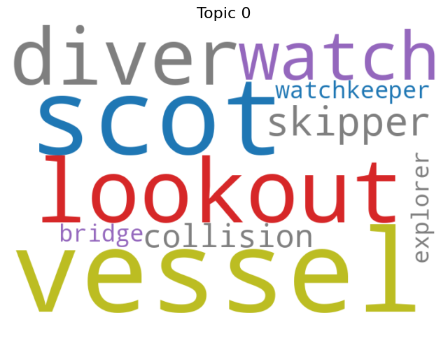

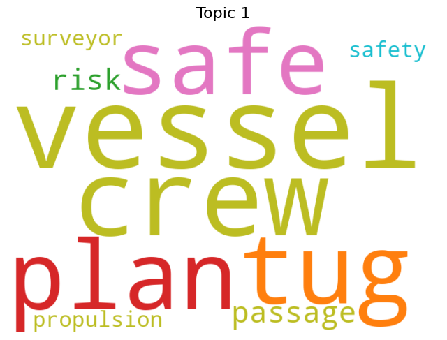

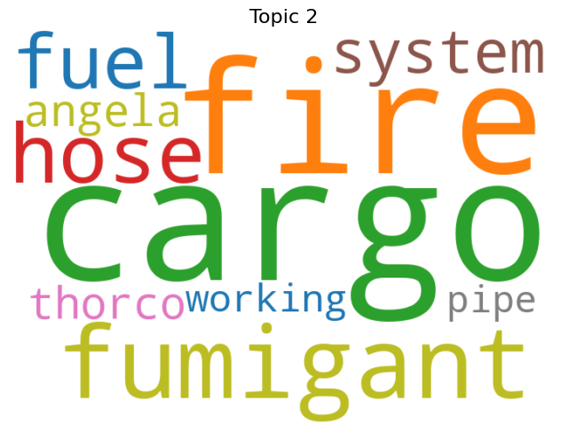

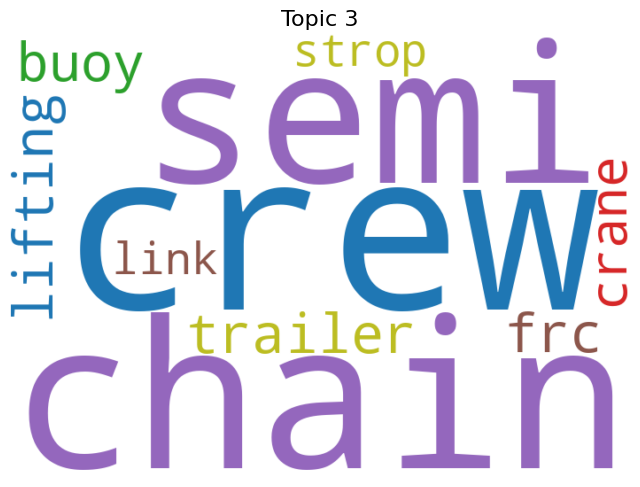

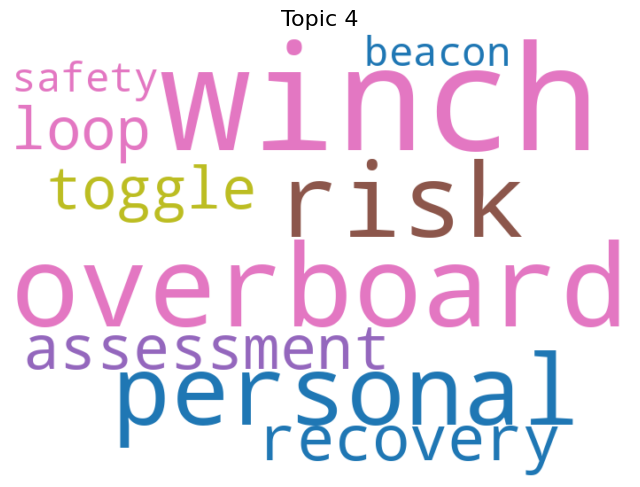

```python
from wordcloud import WordCloud
import matplotlib.pyplot as plt

# Get topic info
topic_info = BER_model.get_topic_info()

# Loop through all topics (skip outlier -1)
for topic_id in topic_info['Topic']:
    if topic_id == -1:
        continue

    # Get words and weights for this topic
    topic_words = BER_model.get_topic(topic_id)  # list of (word, weight)

    if not topic_words:
        continue  # skip empty topics

    # Convert to dictionary and scale weights to make differences more visible
    word_freq = {word: weight * 100 for word, weight in topic_words}

    # Generate WordCloud
    wc = WordCloud(
        width=700,
        height=500,
        background_color='white',
        max_words=50,
        relative_scaling=0.5,
        colormap='tab10'
    )
    wc.generate_from_frequencies(word_freq)

    # Display
    plt.figure(figsize=(8,6))
    plt.imshow(wc, interpolation='bilinear')
    plt.axis('off')
    plt.title(f"Topic {topic_id}", fontsize=16)
    plt.show()
```

The word clouds visually highlight the most influential terms within each BERTopic topic. Frequent words such as diver, lookout, watchkeeper, skipper, and vessel emphasize the importance of human factors and bridge watchkeeping in marine safety incidents. Terms like cargo, fumigant, fuel, and fire reflect high-risk cargo and mechanical hazards that can escalate accidents. The prominence of these words confirms that operational decision-making, crew awareness, and hazardous cargo handling are key contributors to marine accidents. Overall, the word clouds make complex topic modeling results easier to interpret by clearly showing the dominant safety issues across accident reports.

```python
import nbformat
from nbconvert import HTMLExporter

# Load your notebook
notebook_filename = "Final_project_PartIII_Topic Modeling_Bert.ipynb"
nb = nbformat.read(notebook_filename, as_version=4)

# Remove outputs (optional, avoids widget issues)
for cell in nb.cells:
    if "outputs" in cell:
        cell["outputs"] = []

# Create HTML exporter
html_exporter = HTMLExporter()
body, resources = html_exporter.from_notebook_node(nb)

# Save to HTML
html_filename = notebook_filename.replace(".ipynb", ".html")
with open(html_filename, "w", encoding="utf-8") as f:
    f.write(body)

print(f"✅ Notebook exported as {html_filename}")
```

```
✅ Notebook exported as Final_project_PartIII_Topic Modeling_Bert.html
```